# Entregable 3

#### Datos

Los datos han sido obtenidos de las bases de datos de ENDES (Encuesta Demográfica y de Salud Familiar) 2022

Variables que afectal a los embarazos en niñas y adolescentes entre 10 y 19 años en el Perú. La fuente se puede obtener del botón “Fuente de Datos” en la barra de navegación

# ANALISIS UNIVARIADO

#### Analisis Univariado

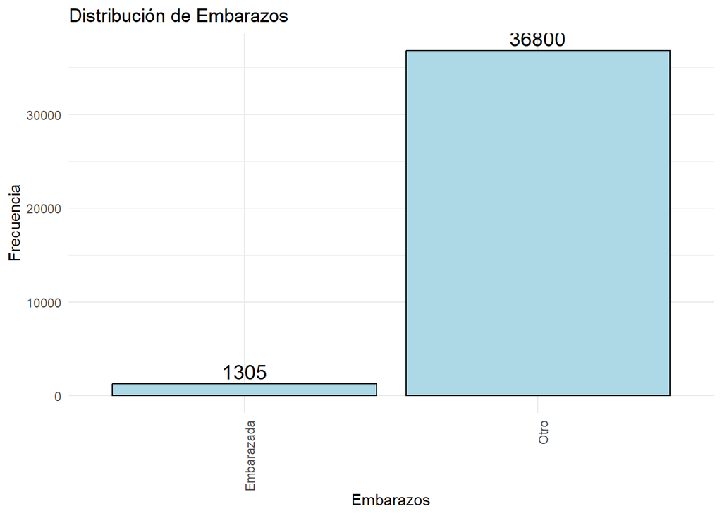

```r
ggplot(data_clean,aes(x=RAZON_DEJAR_ASISTIR))+
  geom_bar(fill="lightblue",color="black")+
  geom_text(stat="count",aes(label=..count..),vjust=-0.3,color="black",size=5)+
  labs(title="Distribución de Embarazos",x="Embarazos",y="Frecuencia")+
  theme_minimal()+
  theme(axis.text.x = element_text(angle=90,hjust=1))
```

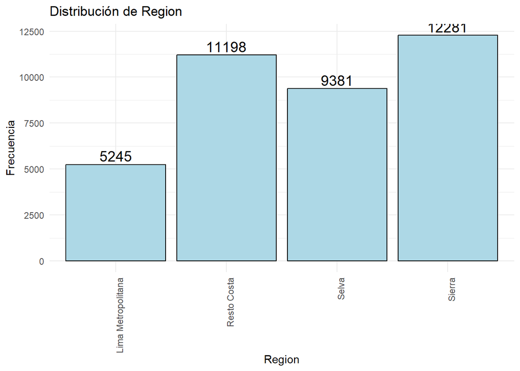

```r
ggplot(data_clean,aes(x=REGION))+
  geom_bar(fill="lightblue",color="black")+
  geom_text(stat="count",aes(label=..count..),vjust=-0.3,color="black",size=5)+
  labs(title="Distribución de Region",x="Region",y="Frecuencia")+
  theme_minimal()+
  theme(axis.text.x = element_text(angle=90,hjust=1))
```

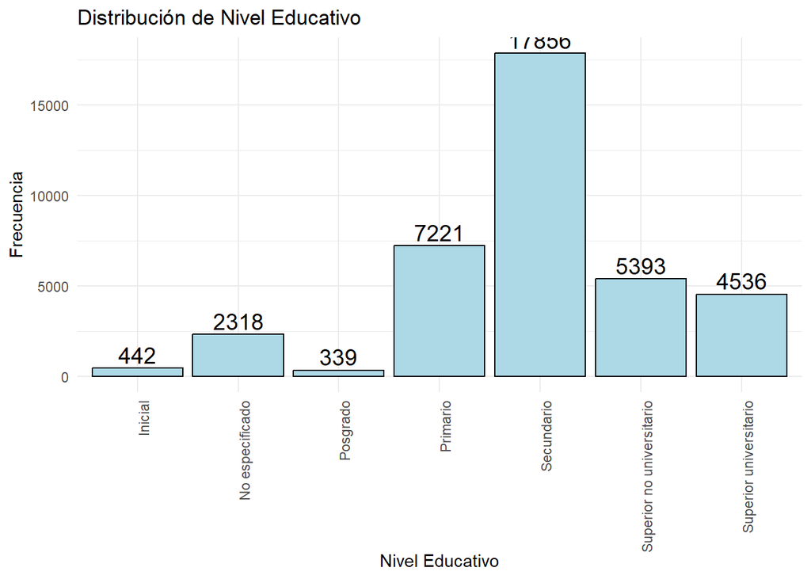

```r
ggplot(data_clean,aes(x=NIVEL_EDUCATIVO))+
  geom_bar(fill="lightblue",color="black")+
  geom_text(stat="count",aes(label=..count..),vjust=-0.3,color="black",size=5)+
  labs(title="Distribución de Nivel Educativo",x="Nivel Educativo",y="Frecuencia")+
  theme_minimal()+
  theme(axis.text.x = element_text(angle=90,hjust=1))
```

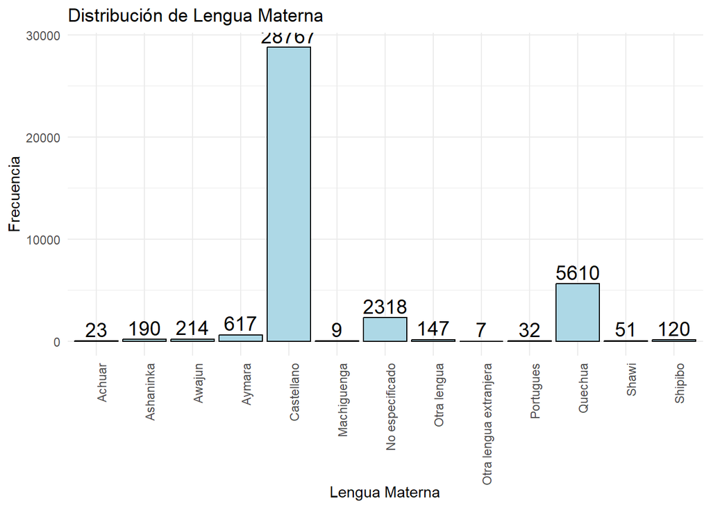

```r
ggplot(data_clean,aes(x=LENGUA_MATERNA))+
  geom_bar(fill="lightblue",color="black")+
  geom_text(stat="count",aes(label=..count..),vjust=-0.3,color="black",size=5)+
  labs(title="Distribución de Lengua Materna",x="Lengua Materna",y="Frecuencia")+
  theme_minimal()+
  theme(axis.text.x = element_text(angle=90,hjust=1))
```

[figure not shown]

```r
ggplot(data_clean,aes(x=IDENTIFICACION))+
  geom_bar(fill="lightblue",color="black")+
  geom_text(stat="count",aes(label=..count..),vjust=-0.3,color="black",size=5)+
  labs(title="Distribución de Lengua Materna",x="Identificación",y="Frecuencia")+
  theme_minimal()+
  theme(axis.text.x = element_text(angle=90,hjust=1))
```

# ANALISIS MULTIVARIADO

#### Analisis Multivariado

Chi Cuadrado - Embarazo y Region

```r
test_region <-chisq.test(data_clean$RAZON_DEJAR_ASISTIR,data_clean$REGION)

test_region
```

```
##
##  Pearson's Chi-squared test
##
## data:  data_clean$RAZON_DEJAR_ASISTIR and data_clean$REGION
## X-squared = 14.681, df = 3, p-value = 0.002111
```

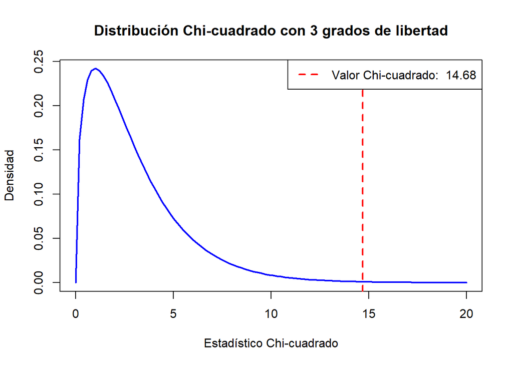

```r
df <- test_region$parameter  # Grados de libertad
x_vals <- seq(0, 20, length.out = 100)
y_vals <- dchisq(x_vals, df)

plot(x_vals, y_vals, type = "l", lwd = 2, col = "blue",
     xlab = "Estadístico Chi-cuadrado", ylab = "Densidad",
     main = paste("Distribución Chi-cuadrado con", df, "grados de libertad"))
abline(v = test_region$statistic, col = "red", lwd = 2, lty = 2)
legend("topright", legend = paste("Valor Chi-cuadrado: ", round(test_region$statistic, 2)),
       col = "red", lty = 2, lwd = 2)
```

Chi Cuadrado - Embarazo y Nivel Educativo

```r
test_educativo <-chisq.test(data_clean$RAZON_DEJAR_ASISTIR,data_clean$NIVEL_EDUCATIVO)

test_educativo
```

```
##
##  Pearson's Chi-squared test
##
## data:  data_clean$RAZON_DEJAR_ASISTIR and data_clean$NIVEL_EDUCATIVO
## X-squared = 734.04, df = 6, p-value < 2.2e-16
```

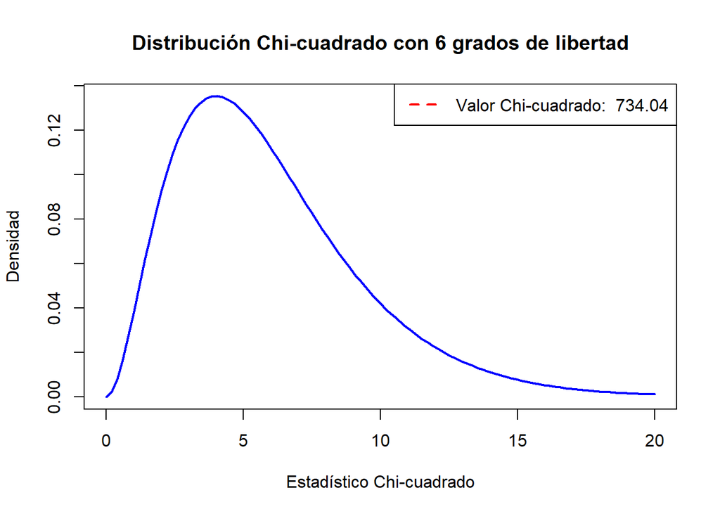

```r
df <- test_educativo$parameter  # Grados de libertad
x_vals <- seq(0, 20, length.out = 100)
y_vals <- dchisq(x_vals, df)

plot(x_vals, y_vals, type = "l", lwd = 2, col = "blue",
     xlab = "Estadístico Chi-cuadrado", ylab = "Densidad",
     main = paste("Distribución Chi-cuadrado con", df, "grados de libertad"))
abline(v = test_educativo$statistic, col = "red", lwd = 2, lty = 2)
legend("topright", legend = paste("Valor Chi-cuadrado: ", round(test_educativo$statistic, 2)),
       col = "red", lty = 2, lwd = 2)
```

Chi Cuadrado - Embarazo y Lengua Materna

```r
test_materna <-chisq.test(data_clean$RAZON_DEJAR_ASISTIR,data_clean$LENGUA_MATERNA)
test_materna
```

```
##
##  Pearson's Chi-squared test
##
## data:  data_clean$RAZON_DEJAR_ASISTIR and data_clean$LENGUA_MATERNA
## X-squared = 98.048, df = 12, p-value = 1.341e-15
```

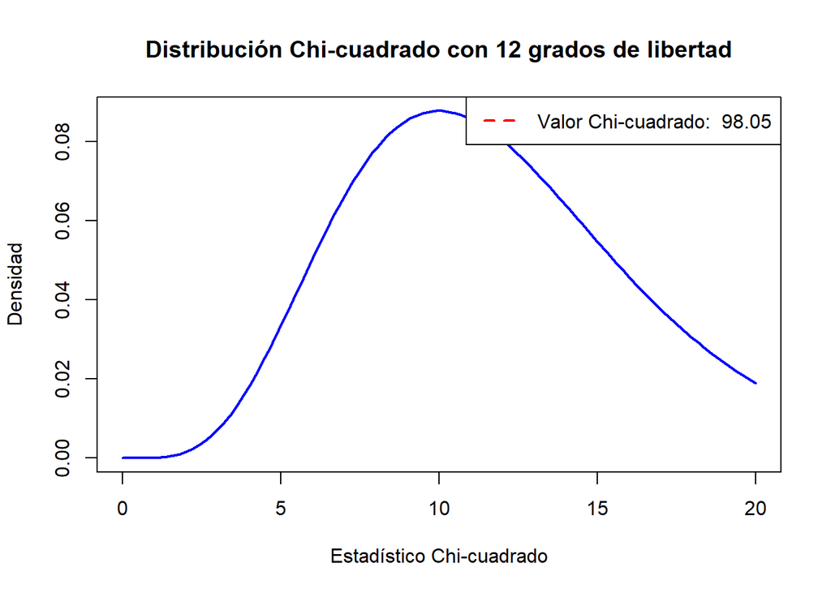

```r
df <- test_materna$parameter  # Grados de libertad
x_vals <- seq(0, 20, length.out = 100)
y_vals <- dchisq(x_vals, df)

plot(x_vals, y_vals, type = "l", lwd = 2, col = "blue",
     xlab = "Estadístico Chi-cuadrado", ylab = "Densidad",
     main = paste("Distribución Chi-cuadrado con", df, "grados de libertad"))
abline(v = test_materna$statistic, col = "red", lwd = 2, lty = 2)
legend("topright", legend = paste("Valor Chi-cuadrado: ", round(test_materna$statistic, 2)),
       col = "red", lty = 2, lwd = 2)
```

Chi Cuadrado - Embarazo y Identificación

```r
test_identificacion <-chisq.test(data_clean$RAZON_DEJAR_ASISTIR,data_clean$IDENTIFICACION)

test_identificacion
```

```
##
##  Pearson's Chi-squared test
##
## data:  data_clean$RAZON_DEJAR_ASISTIR and data_clean$IDENTIFICACION
## X-squared = 103.3, df = 9, p-value < 2.2e-16
```

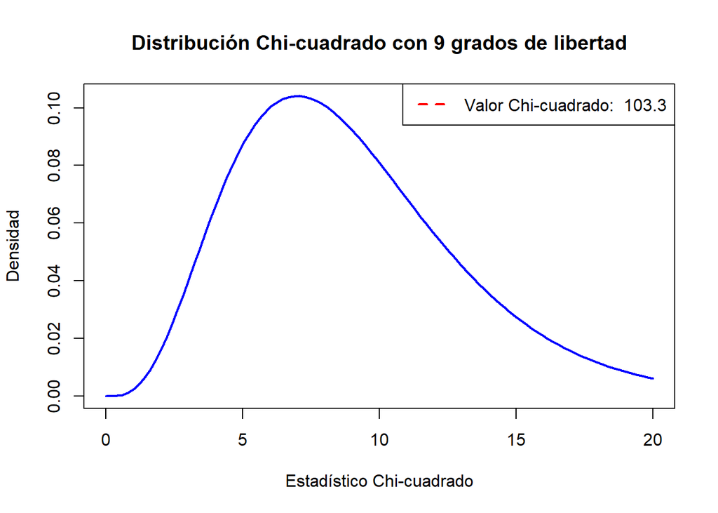

```r
df <- test_identificacion$parameter  # Grados de libertad
x_vals <- seq(0, 20, length.out = 100)
y_vals <- dchisq(x_vals, df)

plot(x_vals, y_vals, type = "l", lwd = 2, col = "blue",
     xlab = "Estadístico Chi-cuadrado", ylab = "Densidad",
     main = paste("Distribución Chi-cuadrado con", df, "grados de libertad"))
abline(v = test_identificacion$statistic, col = "red", lwd = 2, lty = 2)
legend("topright", legend = paste("Valor Chi-cuadrado: ", round(test_identificacion$statistic, 2)),
       col = "red", lty = 2, lwd = 2)
```

Regresión Logística Binaria

```r
modelo_logistico = glm(data_clean$RAZON_DEJAR_ASISTIR ~ data_clean$NIVEL_EDUCATIVO + data_clean$LENGUA_MATERNA + data_clean$IDENTIFICACION, data = data_clean, family = "binomial")
summary(modelo_logistico)
```

```
##
## Call:
## glm(formula = data_clean$RAZON_DEJAR_ASISTIR ~ data_clean$NIVEL_EDUCATIVO +
##     data_clean$LENGUA_MATERNA + data_clean$IDENTIFICACION, family = "binomial",
##     data = data_clean)
##
## Coefficients: (2 not defined because of singularities)
##                                                                      Estimate
## (Intercept)                                                          33.53361
## data_clean$NIVEL_EDUCATIVONo especificado                           -14.96754
## data_clean$NIVEL_EDUCATIVOPosgrado                                   -0.23465
## data_clean$NIVEL_EDUCATIVOPrimario                                  -13.78587
## data_clean$NIVEL_EDUCATIVOSecundario                                -16.00682
## data_clean$NIVEL_EDUCATIVOSuperior no universitario                 -15.02917
## data_clean$NIVEL_EDUCATIVOSuperior universitario                    -14.26577
## data_clean$LENGUA_MATERNAAshaninka                                  -14.92103
## data_clean$LENGUA_MATERNAAwajun                                     -14.78952
## data_clean$LENGUA_MATERNAAymara                                     -14.89361
## data_clean$LENGUA_MATERNACastellano                                 -14.78679
## data_clean$LENGUA_MATERNAMachiguenga                                -16.32427
## data_clean$LENGUA_MATERNANo especificado                                   NA
## data_clean$LENGUA_MATERNAOtra lengua                                -15.19283
## data_clean$LENGUA_MATERNAOtra lengua extranjera                      -0.18245
## data_clean$LENGUA_MATERNAPortugues                                  -15.72155
## data_clean$LENGUA_MATERNAQuechua                                    -14.82622
## data_clean$LENGUA_MATERNAShawi                                      -16.22101
## data_clean$LENGUA_MATERNAShipibo                                    -14.91342
## data_clean$IDENTIFICACIONNo sabe                                     -0.14198
## data_clean$IDENTIFICACIONOtro                                        -0.06211
## data_clean$IDENTIFICACIONProcedencia Afroperuano                      0.02903
## data_clean$IDENTIFICACIONProcedencia Aimara                           0.60453
## data_clean$IDENTIFICACIONProcedencia Blanco                          -0.11536
## data_clean$IDENTIFICACIONProcedencia Mestizo                          0.06759
## data_clean$IDENTIFICACIONProcedencia Nativo o Indigena               -0.36290
## data_clean$IDENTIFICACIONProcedencia Parte de otro pueblo indigena    0.34114
## data_clean$IDENTIFICACIONProcedencia Quechua                               NA
##                                                                    Std. Error
## (Intercept)                                                        1262.83454
## data_clean$NIVEL_EDUCATIVONo especificado                          1270.08077
## data_clean$NIVEL_EDUCATIVOPosgrado                                  467.50550
```

[output cut: 78 more lines]

```
## data_clean$IDENTIFICACIONProcedencia Blanco                          0.3472
## data_clean$IDENTIFICACIONProcedencia Mestizo                         0.4176
## data_clean$IDENTIFICACIONProcedencia Nativo o Indigena               0.1855
## data_clean$IDENTIFICACIONProcedencia Parte de otro pueblo indigena   0.5567
## data_clean$IDENTIFICACIONProcedencia Quechua                             NA
## ---
## Signif. codes:  0 '***' 0.001 '**' 0.01 '*' 0.05 '.' 0.1 ' ' 1
##
## (Dispersion parameter for binomial family taken to be 1)
##
##     Null deviance: 11371  on 38104  degrees of freedom
## Residual deviance: 10465  on 38079  degrees of freedom
## AIC: 10517
##
## Number of Fisher Scoring iterations: 17
```

# CONCLUSIONES

#### Conclusiones

##### Analisis Univariado

Sobre el análisis univariado se ha analizado cada variable de manera independiente :

1.Embarazos : Dentro de los datos obtenidos, se puede ver que la proporciòn de embarazadas no es tanta ya que son 1,305 embarazadas y 36,800 no embarazadas. Esto significa que el 3.4% de encuestadas son embarazadas

2.Regiòn : Vemos que entre las regiones hay una gran variedad de encuestadas. Particularmente hay muchas encuestadas de la Sierra y Resto de Costa. El menor nùmero de encuestadas està en Lima Metrpolitana

3.Lengua Materna : En cuanto a lengua materna, la mayoría hablan castellano.

#### Analisis Multivariado

Sobre el analisis multivariado, se han hecho los análisis de chi cuadrado y regresión logística

1.Chi Cuadrado 1.1. Embarazo y Región El valor del p-value de 0.002111 indica que hay una asociación estadísticamente significativa entre estas dos variables categóricas

1.2.Embarazo y Lengua Materna

El valor del p-value (1.341e-15) indica que hay una relación estadísticamente significativa entre ambas variables

1.3.Embarazo y Identificación

El valor del p-value (2.2e-16) indica que hay una relación estadísticamente significativa entre ambas variables

2.Regresión Logística

2.1. Aimara Se indica que aquellas personas que se identifican con el grupo de Aimara tienen un p-valor de 0.0486 , lo que es significativo.

2.2. Demás categorías Las demas categorias de las demas variables no han mostrado una relación particularmente grande por tener un p-valor muy alto.